# Influence of sample size on strong correlations

Joaquim Aguirre-Plans

2024-09-28

## Description

Analysis on strong correlations across sample size.

```r
#packrat::init("/home/j.aguirreplans/Projects/Scipher/SampleSize/scripts/SampleSizeR")
```

```r
library(data.table)
library(dplyr)
```

```r
library(ggplot2)
library(patchwork)
set.seed(1510)
options(bitmapType='cairo')
```

## Load functions

```r
#'  calculate_predictions_using_stretched_exponential_model_optimized
#'  Formula to calculate exponential decay of significant interactions from a list of sample sizes.
#'  This formula requires the use of the L parameter
#'  @param x List of sample sizes.
#'  @param a Slope coefficient.
#'  @param b Intercept coefficient.
#'
calculate_predictions_using_stretched_exponential_model_optimized = function(x, L, a, b){
  y = L * exp((b * x ** (-a + 1)) / (-a + 1))
  #y = exp(log(L) - exp(b+a*log(x)))
  return(y)
}

#'  calculate_prediction_from_analytical_model
#'  Function to calculate predictions using a specific analytical model
#'  @param model Name of the model used.
#'  @param x_list List of values in the x axis (e.g. size)
#'  @param a Parameter a.
#'  @param b Parameter b.
#'  @param L Parameter L.
#'
calculate_prediction_from_analytical_model = function(model, x_list, a, b, L){
  if(model == "Logarithmic"){
    prediction_result = (log(x_list)*a + b)
  } else if(model == "Linear"){
    prediction_result = (x_list*a + b)
  } else if(model == "Exponential"){
    prediction_result = (exp((x_list*a + b)))
  } else if(model == "Square root"){
    prediction_result = (exp((log(x_list)*a + b)))
  } else if((model == "Stretched exponential (by optimization)") | (model == "Stretched exponential (by linear fit)")){
    prediction_result = calculate_predictions_using_stretched_exponential_model_optimized(x=x_list, L=L, a=a, b=b)
  } else if(model == "Stretched exponential (without L)"){
    prediction_result = calculate_predictions_using_stretched_exponential_model_without_L(x=x_list, a=a, b=b)
  } else if(model == "Exponential decay"){
    prediction_result = calculate_predictions_using_exponential_decay_model(x=x_list, L=L, a=a, b=b)
  }
  return(prediction_result)
}
```

## Load data

```r
input_dir <- '/home/j.aguirreplans/Projects/Scipher/SampleSize/scripts/SampleSizeShiny/data'
example_dir <- paste(input_dir, 'example_pearson_pval_0.05', sep = "/")
plots_dir <- '/home/j.aguirreplans/Projects/Scipher/SampleSize/data/out/plots'
tables_dir <- '/home/j.aguirreplans/Projects/Scipher/SampleSize/data/out/tables'
font_selected <- "Helvetica"
model_selected <- "Stretched exponential (by linear fit)"
topology_type_normalization <- "divide.L"
#datasets_selected = c("gtex:breast.mammary.tissue_female",
#                      "gtex:lung",
#                      "tcga:tcga-brca_female",
#                      "tcga:tcga-luad",
#                      "scipher:scipher.sample.per.patient.baseline")
datasets_selected = c("gse193677:rectum_inflamed",
                      "gtex:breast.mammary.tissue_female",
                      "gtex:lung",
                      "tcga:tcga-brca_female")
all_datasets <- c(
  "scipher:scipher.sample.per.patient.baseline",
  "gse193677:rectum_cd_inflamed",
  "gse193677:rectum_uc_inflamed",
  "gse193677:rectum_control_noninflamed",
  "gse193677:rectum_inflamed",
  "gse193677:rectum_noninflamed",
  "gtex:breast.mammary.tissue_female",
  "gtex:lung",
  "gtex:skin.sun.exposed.lower.leg",
  "gtex:thyroid",
  "gtex:whole.blood",
  "tcga:tcga-brca_female",
  "tcga:tcga-kirc",
  "tcga:tcga-kirp",
  "tcga:tcga-luad",
  "tcga:tcga-lusc",
  "tcga:tcga-thca",
  "tcga:breast_female",
  "tcga:kidney",
  "tcga:lung",
  "tcga:brca.luma",
  "tcga:brca.lumb"
)

id2name <- c(
  "gtex:breast.mammary.tissue_female" = "GTEx: Breast",
  "gtex:whole.blood" = "GTEx: Whole blood",
  "gtex:lung" = "GTEx: Lung",
  "tcga:tcga-brca_female" = "TCGA: Breast cancer",
  "tcga:tcga-luad" = "TCGA: Lung cancer",
  "scipher:scipher.sample.per.patient.baseline" = "R. arthritis",
  "gse193677:rectum_uc_inflamed" = "UC inflamed",
  "gse193677:rectum_inflamed" = "UC/CD inflamed",
  "spearman" = "Spearman",
  "pearson" = "Pearson",
  "aracne" = "ARACNe",
  "genie3" = "GENIE3"
)

name2color <- c(
  "TCGA: Lung cancer" = "#56B4E9",
  "tcga:tcga-luad" = "#56B4E9",
  "tcga:tcga-luad-tumor" = "#56B4E9", # #D55E00
  "TCGA: Breast cancer" = "#0072B2",
  "TCGA: Breast c." = "#0072B2",
  "tcga:tcga-brca_female" = "#0072B2",
  "tcga:tcga-brca-tumor_female" = "#0072B2",
  "breast neoplasms"="#0072B2",
  "gse193677" = "#E032EC",
  "GSE193677" = "#E032EC",
  "gse193677:rectum_uc_inflamed" = "#E032EC",
  "gse193677:rectum_inflamed" = "#E032EC",
  "UC inflamed" = "#E032EC",
  "Rectum inflamed" = "#E032EC",
  "UC/CD inflamed" = "#E032EC",
  "GTEx: Whole blood" = "#65F3BF",
  "gtex:whole.blood" = "#65F3BF",
  "GTEx: Lung" = "#077d2b",
  "gtex:lung" = "#077d2b",
  "GTEx: Breast" = "#00BA37", #44AA99
  "gtex:breast.mammary.tissue" = "#00BA37",
  "gtex:breast.mammary.tissue_female" = "#00BA37",
  "R. arthritis" = "#D55E00", #E69F00
  "scipher:scipher.sample.per.patient.baseline" = "#D55E00",
  "arthritis rheumatoid"="#D55E00",
  "asthma"="#d9f365",
  "thyroid neoplasms"="#0072B2",
  "tcga" = "#0072B2",
  "TCGA" = "#0072B2",
  "gtex" = "#00BA37",
  "GTEx" = "#00BA37",
  "scipher" = "#D55E00",
  #"Analytical model"="#e3f705",
  "Analytical model"="#cc68f7",
  "Power law"="#cc68f7",
  "Logarithm"="#09b863",
  "Exponential decay"="#09b863",
  "\u2265 0.2" = "#F8766D",
  "\u2265 0.4" = "#7CAE00",
  "\u2265 0.6" = "#00BFC4",
  "\u2265 0.8" = "#C77CFF",
  "Very Weak" = "#ff7b00",
  "Weak" = "#F8766D",
  "Moderate" = "#7CAE00",
  "Strong" = "#00BFC4",
  "Very Strong" = "#C77CFF",
  "Convergence point" = "red",
  "Model prediction" = "red",
  "P-value < 0.05" = "red",
  "common" = "#619CFF",
  "disease-gene" = "#cc68f7",
  "disease-specific" = "#F8766D",
  "normal-specific" = "#00BA38",
  "undefined" = "#808080",
  "different" = "#C77CFF",
  "all" = "#CD9600",
  "common (constant)" = "#619CFF",
  "common (change)" = "#b5d1ff",
  "disease-specific (constant)" = "#F8766D",
  "disease-specific (change)" = "#ffcbc7",
  "normal-specific (constant)" = "#00BA38",
  "normal-specific (change)" = "#a3d1b1",
  "undefined (constant)" = "#808080",
  "undefined (change)" = "#c2c2c2",
  "pearson" = "#a57212",
  "spearman" = "#f5c977",
  "genie3" = "#f5a14f",
  "aracne" = "#e35512"
  )
```

## Significance of strong correlations vs. sample size

Load data on analytical model parameters:

```r
analytical_results_file <- paste(example_dir, '/', 'analytical_model_results_', topology_type_normalization, '_pearson_pval_0.05.txt', sep='')
analytical_results_df <- data.table::fread(analytical_results_file) %>%
  dplyr::filter((model == model_selected) & (type_dataset %in% all_datasets)) %>%
  dplyr::select(type_dataset, max_value_in_dataset, a, b, L, slope, intercept) %>%
  unique()
head(analytical_results_df)
```

```
##                                   type_dataset max_value_in_dataset        a
##                                         <char>                <int>    <num>
## 1: scipher:scipher.sample.per.patient.baseline             40568917 1.758283
## 2:           gtex:breast.mammary.tissue_female             42299605 1.811947
## 3:                                   gtex:lung             82744314 1.654318
## 4:             gtex:skin.sun.exposed.lower.leg            109822205 1.836919
## 5:                                gtex:thyroid             95645379 1.746114
## 6:                            gtex:whole.blood             72312862 1.650687
##           b        L      slope intercept
##       <num>    <num>      <num>     <num>
## 1: 41.83477 2.332343 -0.7582829  4.010427
## 2: 64.89496 3.885985 -0.8119469  4.381090
## 3: 28.07262 1.964261 -0.6543181  3.758956
## 4: 69.54141 1.443081 -0.8369185  4.419951
## 5: 46.00874 1.669286 -0.7461144  4.121708
## 6: 21.33857 1.586486 -0.6506871  3.490243
```

Load predictions of the critical sample sizes for a given correlation strength:

```r
theoretical_sample_size_file <- paste(example_dir, 'theoretical_sample_size_for_correlations_of_datasets.txt', sep='/') # from => calculate_convergence_correlation_types.Rmd
theoretical_sample_size_df <- data.table::fread(theoretical_sample_size_file) %>%
  dplyr::rename(type_dataset = dataset) %>%
  filter((type_correlation == "strong") & (type_dataset %in% all_datasets)) %>%
  dplyr::select(type_dataset, sample_size_statistical_corrected) %>%
  unique()
head(theoretical_sample_size_df)
```

```
##                                   type_dataset
##                                         <char>
## 1: scipher:scipher.sample.per.patient.baseline
## 2:                       tcga:tcga-brca_female
## 3:                              tcga:tcga-kirc
## 4:                              tcga:tcga-kirp
## 5:                              tcga:tcga-luad
## 6:                              tcga:tcga-lusc
##    sample_size_statistical_corrected
##                                <num>
## 1:                          85.87258
## 2:                          88.74980
## 3:                          88.83721
## 4:                          88.48554
## 5:                          88.78724
## 6:                          88.93943
```

```r
mean(theoretical_sample_size_df$sample_size_statistical_corrected)
```

```
## [1] 88.34551
```

```r
quantile(theoretical_sample_size_df$sample_size_statistical_corrected)
```

```
##       0%      25%      50%      75%     100%
## 85.87258 88.29451 88.40176 88.77401 89.06788
```

Calculate predicted fraction of significant correlations for given sample sizes:

```r
predicted_results_df = data.frame()
for (type_dataset_sel in datasets_selected) {
  max_size <- round(theoretical_sample_size_df[theoretical_sample_size_df$type_dataset == type_dataset_sel]$sample_size_statistical_corrected)
  N_vals <- seq(3, max_size, 1)
  a_sel <- analytical_results_df[analytical_results_df$type_dataset == type_dataset_sel]$a
  b_sel <- analytical_results_df[analytical_results_df$type_dataset == type_dataset_sel]$b
  L_sel <- analytical_results_df[analytical_results_df$type_dataset == type_dataset_sel]$L
  max_value_in_dataset <- analytical_results_df[analytical_results_df$type_dataset == type_dataset_sel]$max_value_in_dataset
  prediction_result = calculate_prediction_from_analytical_model(
    model = model_selected,
    x_list = N_vals,
    a = a_sel,
    b = b_sel,
    L = L_sel
  )
  predicted_results_df <- rbind(
    predicted_results_df,
    data.frame(
      type_dataset = type_dataset_sel,
      size = N_vals,
      model_result = prediction_result * max_value_in_dataset
    )
  )
}

head(predicted_results_df)
```

```
##                type_dataset size model_result
## 1 gse193677:rectum_inflamed    3 1.278963e-09
## 2 gse193677:rectum_inflamed    4 2.201078e-05
## 3 gse193677:rectum_inflamed    5 7.791248e-03
## 4 gse193677:rectum_inflamed    6 3.934485e-01
## 5 gse193677:rectum_inflamed    7 6.514309e+00
## 6 gse193677:rectum_inflamed    8 5.365525e+01
```

Join all information on the same data frame:

```r
# Join analytical and theoretical tables and filter out model predictions above
# the maximum sample size predicted for "strong" edges
predicted_results_mod_df <- predicted_results_df %>%
  dplyr::inner_join(analytical_results_df, by = c("type_dataset")) %>%
  dplyr::inner_join(theoretical_sample_size_df, by = c("type_dataset")) %>%
  dplyr::rename("model_num_edges" = "model_result") %>%
  dplyr::mutate(model_frac_edges = (model_num_edges / max_value_in_dataset) / L) %>%
  dplyr::filter((type_dataset %in% datasets_selected) & (size <= sample_size_statistical_corrected))

rm(predicted_results_df)
rm(analytical_results_df)
rm(theoretical_sample_size_df)

# Calculate maximum number of "strong" edges
predicted_results_mod_df$max_frac_strong_edges <- calculate_predictions_using_stretched_exponential_model_optimized(
  x = predicted_results_mod_df$sample_size_statistical_corrected,
  L = predicted_results_mod_df$L,
  a = predicted_results_mod_df$a,
  b = predicted_results_mod_df$b
)
# Normalize maximum number of strong edges
predicted_results_mod_df$max_frac_strong_edges <- predicted_results_mod_df$max_frac_strong_edges / predicted_results_mod_df$L
# Calculate fraction of strong edges
predicted_results_mod_df$frac_strong_edges_model <- predicted_results_mod_df$model_frac_edges / predicted_results_mod_df$max_frac_strong_edges

head(predicted_results_mod_df)
```

```
##                type_dataset size model_num_edges max_value_in_dataset        a
## 1 gse193677:rectum_inflamed    3    1.278963e-09             97523476 1.988577
## 2 gse193677:rectum_inflamed    4    2.201078e-05             97523476 1.988577
## 3 gse193677:rectum_inflamed    5    7.791248e-03             97523476 1.988577
## 4 gse193677:rectum_inflamed    6    3.934485e-01             97523476 1.988577
## 5 gse193677:rectum_inflamed    7    6.514309e+00             97523476 1.988577
## 6 gse193677:rectum_inflamed    8    5.365525e+01             97523476 1.988577
##          b        L     slope intercept sample_size_statistical_corrected
## 1 115.3985 1.697605 -0.988577   4.75988                          88.31798
## 2 115.3985 1.697605 -0.988577   4.75988                          88.31798
## 3 115.3985 1.697605 -0.988577   4.75988                          88.31798
## 4 115.3985 1.697605 -0.988577   4.75988                          88.31798
## 5 115.3985 1.697605 -0.988577   4.75988                          88.31798
## 6 115.3985 1.697605 -0.988577   4.75988                          88.31798
##   model_frac_edges max_frac_strong_edges frac_strong_edges_model
## 1     7.725243e-18             0.2487919            3.105102e-17
## 2     1.329504e-13             0.2487919            5.343839e-13
## 3     4.706101e-11             0.2487919            1.891581e-10
## 4     2.376524e-09             0.2487919            9.552255e-09
## 5     3.934800e-08             0.2487919            1.581562e-07
## 6     3.240906e-07             0.2487919            1.302657e-06
```

Show critical sample size values for the data sets selected:

```r
predicted_results_mod_df %>%
  dplyr::select(type_dataset, sample_size_statistical_corrected) %>%
  unique()
```

```
##                          type_dataset sample_size_statistical_corrected
## 1           gse193677:rectum_inflamed                          88.31798
## 87  gtex:breast.mammary.tissue_female                          88.28668
## 173                         gtex:lung                          88.23735
## 259             tcga:tcga-brca_female                          88.74980
```

Plot fraction of significant strong correlations vs. sample size for the data sets selected:

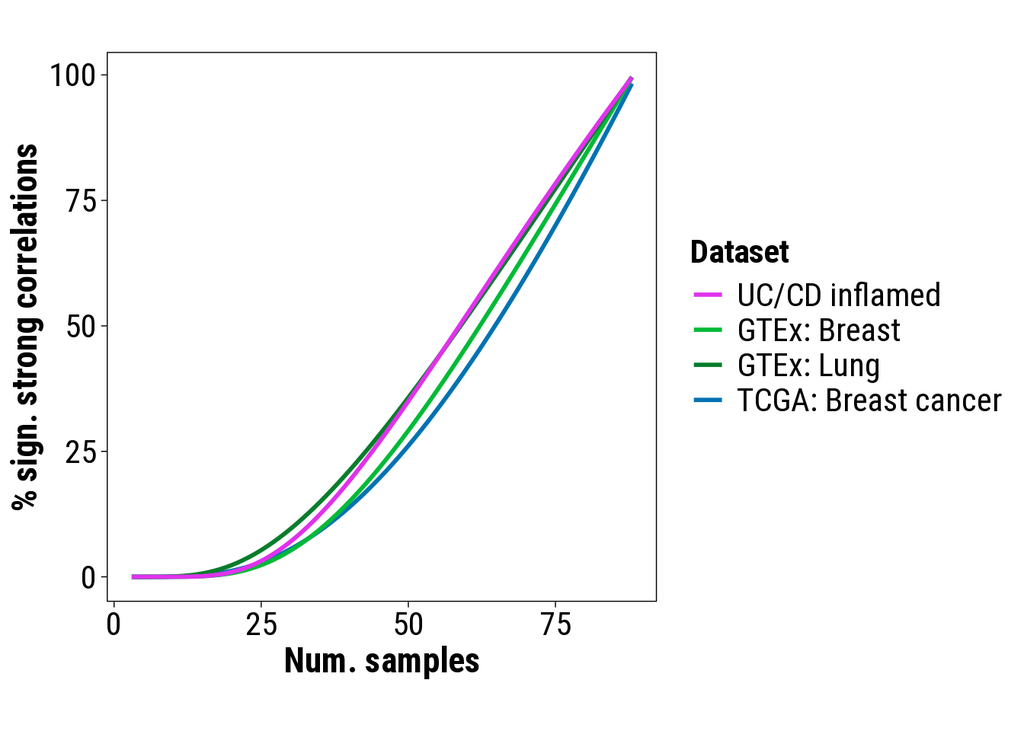

```r
predicted_results_mod_df <- predicted_results_mod_df %>%
  inner_join( (name2color %>%
                 as.data.frame() %>%
                 dplyr::rename("rgb_col"=".") %>%
                 tibble::rownames_to_column("type_dataset")),
              by=c("type_dataset") ) %>%
  dplyr::mutate(type_dataset = dplyr::recode(type_dataset, !!!id2name))

significance_strong_corr_plot <- predicted_results_mod_df %>%
  ggplot(aes(x = size, y = frac_strong_edges_model * 100)) +
  geom_line(aes(col = rgb_col), size=1) +
  scale_colour_identity(
    labels = unique(predicted_results_mod_df$type_dataset),
    breaks = unique(predicted_results_mod_df$rgb_col),
    guide = "legend"
  ) +
  xlab("Num. samples") +
  ylab("% sign. strong correlations") +
  guides(col=guide_legend(title="Dataset")) +
  theme_linedraw() +
  theme(aspect.ratio = 1,
        plot.title =  element_text(size = 20, face = "bold"),
        axis.title = element_text(size = 17, face = "bold"),
        axis.text = element_text(size = 16),
        panel.grid.major = element_blank(),
        panel.grid.minor = element_blank(),
        text = element_text(family = font_selected),
        legend.text = element_text(size = 16),
        legend.title=element_text(size=16, face="bold")
  )
print(significance_strong_corr_plot)
```

## Percentage of remaining strong scores in smaller sample sizes

```r
dataset_to_file_names <- list(
  "tcga:tcga-brca_female" = "/scratch/j.aguirreplans/Scipher/SampleSizeProject/networks_tcga/reads/tumor/tcga_TCGA-BRCA_female",
  "gtex:lung" = "/scratch/j.aguirreplans/Scipher/SampleSizeProject/networks_gtex/reads/gtex_Lung",
  "gtex:breast.mammary.tissue_female" = "/scratch/j.aguirreplans/Scipher/SampleSizeProject/networks_gtex/reads/gtex_Breast.Mammary.Tissue",
  "gse193677:rectum_inflamed" = "/scratch/j.aguirreplans/Scipher/SampleSizeProject/networks_geo/GSE193677/reads/inflamed_vs_noninflamed/gse193677_Rectum_inflamed"
)
methods_selected <- c("pearson", "spearman", "aracne", "genie3")
method_to_thresholds <- list(
  "pearson" = c(0.6),
  "spearman" = c(0.6),
  "aracne" = c(1),
  "genie3" = c(0.01)
)
```

For networks based on different methods (Pearson, Spearman, ARACNe, GENIE3) and data sets, read the files where the select strong correlations have already been selected as the ones above a given threshold (e.g., 0.6 for pearson) at all networks for sizes 140-240. Then, join with the ones for sizes 20-120. Finally, calculate the percentage of remaining strong correlations at lower sample sizes

```r
perc_remaining_strong_scores_file <- "/home/j.aguirreplans/Projects/Scipher/SampleSize/data/out/tables/analysis_percentage_remaining_strong_scores_filtered_size240.txt"
large_sample_columns <- c("240.1", "240.2", "240.3", "240.4", "240.5")
perc_remaining_strong_scores_df <- data.frame()

if (!(file.exists(perc_remaining_strong_scores_file))) {
  for (method_sel in methods_selected) {
    threshold_sel <- method_to_thresholds[[method_sel]]
    for (type_dataset_sel in names(dataset_to_file_names)) {

      # Read filtered networks
      merged_networks_file1 <- paste(
        dataset_to_file_names[[type_dataset_sel]],
        "_",
        method_sel,
        "_combined.txt",
        sep = ""
      )

      merged_networks_file2 <- paste(
        dataset_to_file_names[[type_dataset_sel]],
        "_",
        method_sel,
        "_combined_filtered_by_threshold_",
        threshold_sel,
        "_140-240.txt",
        sep = ""
      )

      if (file.exists(merged_networks_file1) & file.exists(merged_networks_file2)) {
        # Read networks with all links from sizes 20 to 120
        networks_df <- data.table::fread(merged_networks_file1, header = TRUE) %>%
          # Make a right join with the networks from sizes 140 to 240 filtered
          # by strong correlations
          dplyr::right_join(
            (data.table::fread(merged_networks_file2, header = TRUE) %>%
                dplyr::filter(dplyr::if_all(large_sample_columns, ~ abs(.) >= abs(threshold_sel)))),
            by = c("Node.1", "Node.2")
          )

        cols <- colnames(networks_df)
        score_cols <- cols[!(cols %in% c("Node.1", "Node.2"))]
        if (threshold_sel == 0) {
          remaining_strong_scores_subset_df <- as.data.frame(colSums(abs(networks_df[, ..score_cols]) > threshold_sel) / nrow(networks_df[, ..score_cols]) * 100)
        } else {
          remaining_strong_scores_subset_df <- as.data.frame(colSums(abs(networks_df[, ..score_cols]) >= threshold_sel) / nrow(networks_df[, ..score_cols]) * 100)
        }
        remaining_strong_scores_subset_df$ss.rep <- row.names(remaining_strong_scores_subset_df)
        row.names(remaining_strong_scores_subset_df) <- NULL
        colnames(remaining_strong_scores_subset_df) <- c("percentage_above_threshold", "ss.rep")
        remaining_strong_scores_subset_df <- remaining_strong_scores_subset_df %>%
          tidyr::separate("ss.rep", into=c("ss", "rep"), sep="[.]") %>%
          dplyr::mutate(
            ss = as.numeric(ss),
            rep = as.numeric(rep),
            method = method_sel,
            threshold = threshold_sel,
            type_dataset = type_dataset_sel
          )
        rm(networks_df)

        perc_remaining_strong_scores_df <- rbind(
          perc_remaining_strong_scores_df,
          remaining_strong_scores_subset_df
        )
      } else {
        print(paste("The following merged networks files do not exist:", merged_networks_file1, merged_networks_file2))
      }
    }
  }

  perc_remaining_strong_scores_df %>% data.table::fwrite(perc_remaining_strong_scores_file, sep = "\t")

} else {
  perc_remaining_strong_scores_df <- data.table::fread(perc_remaining_strong_scores_file, header = TRUE)
}
head(perc_remaining_strong_scores_df)
```

```
##    percentage_above_threshold    ss   rep  method threshold
##                         <num> <int> <int>  <char>     <num>
## 1:                   81.32775    20     1 pearson       0.6
## 2:                   75.23847    20     2 pearson       0.6
## 3:                   85.35938    20     3 pearson       0.6
## 4:                   59.38070    20     4 pearson       0.6
## 5:                   68.69567    20     5 pearson       0.6
## 6:                   70.39961    40     1 pearson       0.6
##             type_dataset
##                   <char>
## 1: tcga:tcga-brca_female
## 2: tcga:tcga-brca_female
## 3: tcga:tcga-brca_female
## 4: tcga:tcga-brca_female
## 5: tcga:tcga-brca_female
## 6: tcga:tcga-brca_female
```

### Percentage of remaining strong scores for each method across data sets

```
## [1] "pearson"
```

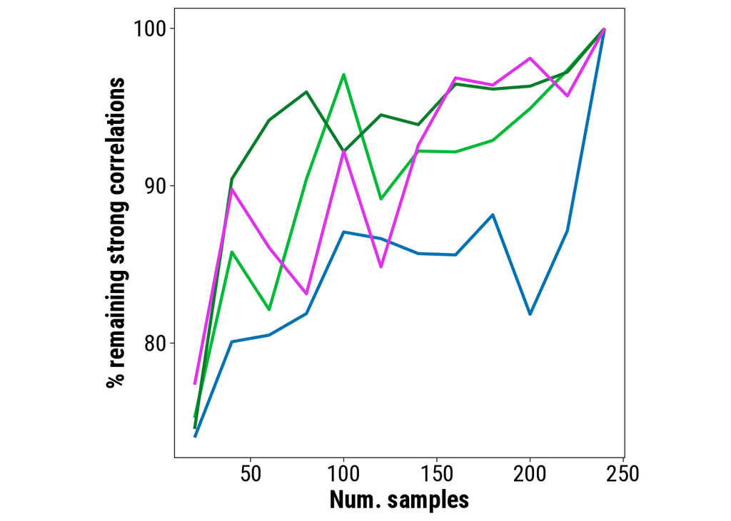

```
## [1] "spearman"
```

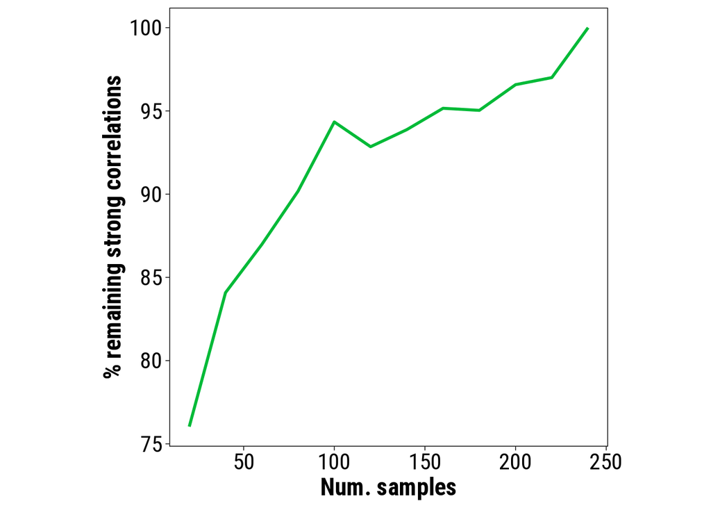

```
## [1] "aracne"
```

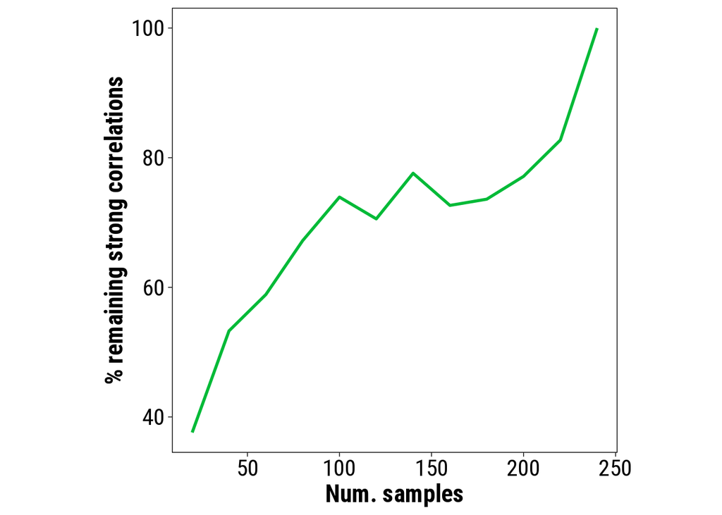

```
## [1] "genie3"
```

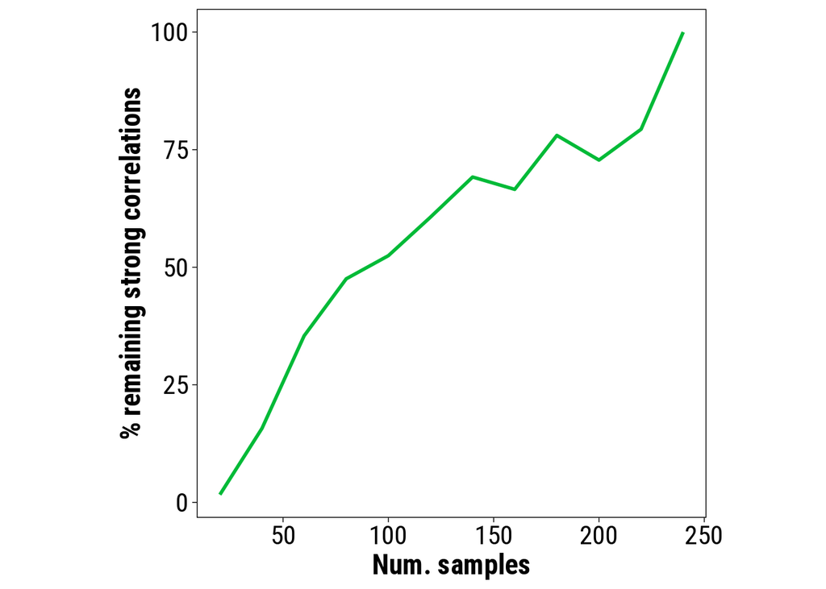

```r
perc_remaining_strong_scores_by_method_plot <- list()

for (method_sel in unique(perc_remaining_strong_scores_df$method)) {
  print(method_sel)

  perc_remaining_strong_scores_by_method_df <- perc_remaining_strong_scores_df %>%
    dplyr::filter(method == method_sel) %>%
    dplyr::group_by(type_dataset, ss) %>%
    dplyr::summarize(
      mean_percent = mean(percentage_above_threshold),
      sd_percent = sd(percentage_above_threshold)
    ) %>%
    dplyr::ungroup() %>%
    dplyr::inner_join( (name2color %>%
                          as.data.frame() %>%
                          dplyr::rename("rgb_col"=".") %>%
                          tibble::rownames_to_column("type_dataset")),
                       by=c("type_dataset") ) %>%
    dplyr::mutate(
      ss = as.numeric(ss),
      type_dataset = dplyr::recode(type_dataset, !!!id2name)
    )

  perc_remaining_strong_scores_by_method_plot[[method_sel]] <- perc_remaining_strong_scores_by_method_df %>%
    ggplot(aes(x = ss, y = mean_percent, group = rgb_col)) +
    geom_line(aes(col = rgb_col), size = 1) +
    scale_colour_identity(
      labels = unique(perc_remaining_strong_scores_df$type_dataset),
      breaks = unique(perc_remaining_strong_scores_df$rgb_col),
      guide = "legend"
    ) +
    xlab("Num. samples") +
    ylab("% remaining strong correlations") +
    guides(col=guide_legend(title="Dataset")) +
    theme_linedraw() +
    theme(aspect.ratio = 1,
          plot.title =  element_text(size = 20, face = "bold"),
          axis.title = element_text(size = 17, face = "bold"),
          axis.text = element_text(size = 16),
          panel.grid.major = element_blank(),
          panel.grid.minor = element_blank(),
          text = element_text(family = font_selected),
          legend.text = element_text(size = 16),
          legend.title=element_text(size=16, face="bold")
    )

  rm(perc_remaining_strong_scores_by_method_df)

  print(perc_remaining_strong_scores_by_method_plot[[method_sel]])
}
```

### Percentage of remaining strong scores for each data set across methods

Plot the % of remaining strong correlations vs. sample size across different methods (selecting networks from the same data set):

```
## [1] "gse193677:rectum_inflamed"
```

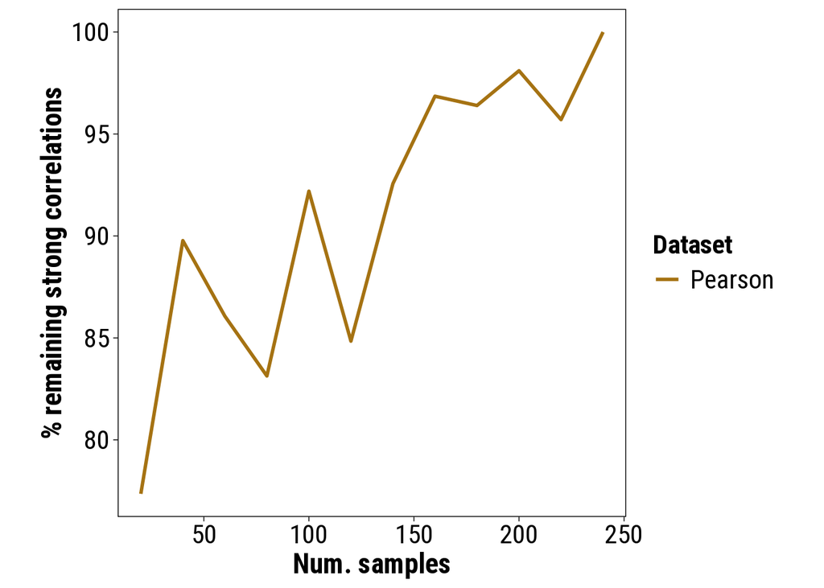

```
## [1] "gtex:breast.mammary.tissue_female"
```

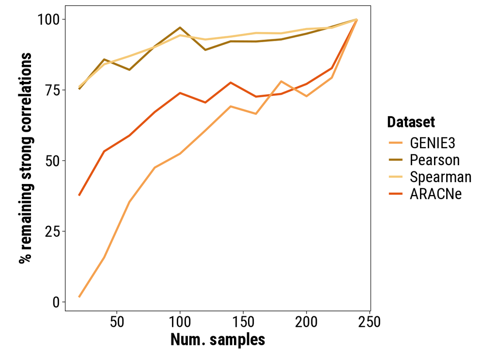

```
## [1] "gtex:lung"
```

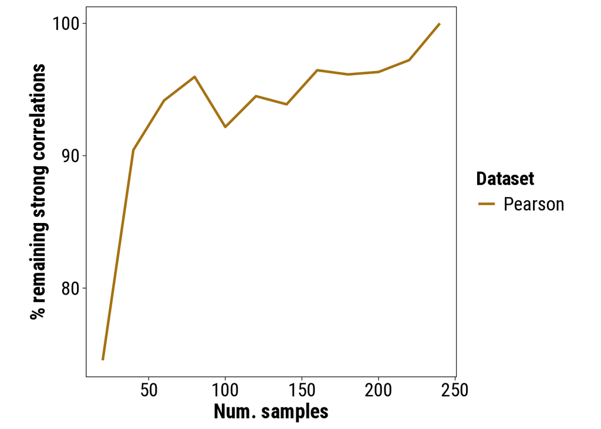

```
## [1] "tcga:tcga-brca_female"
```

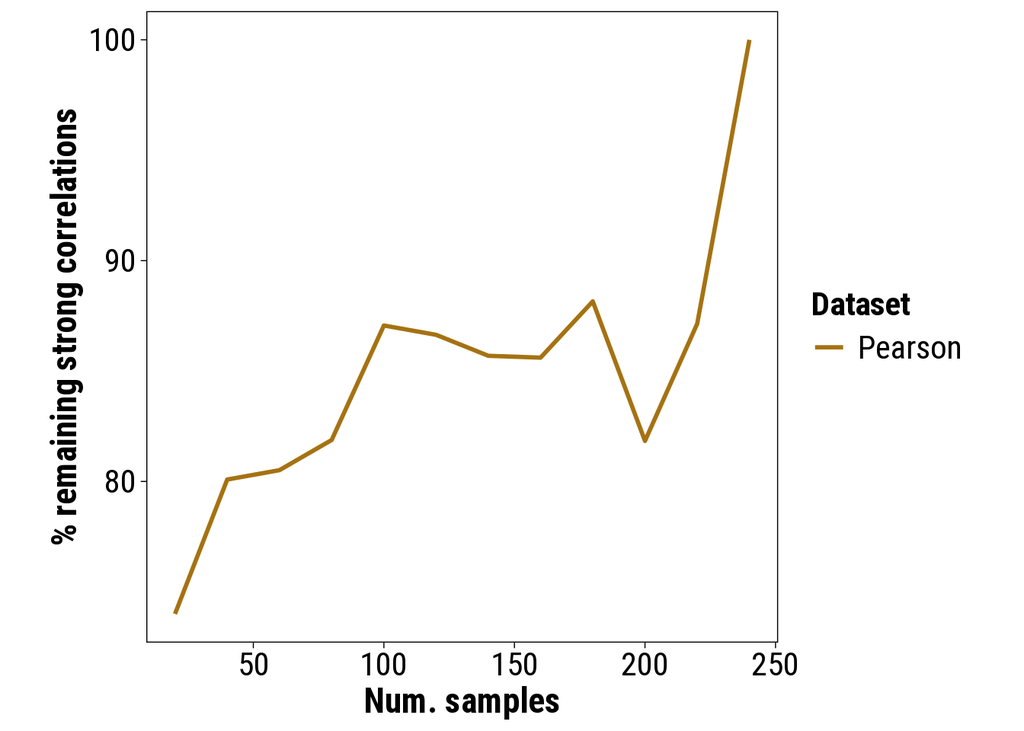

```r
perc_remaining_strong_scores_by_dataset_plot <- list()
for (i in 1:length(datasets_selected)){
  type_dataset_sel = datasets_selected[[i]]
  print(type_dataset_sel)

  perc_remaining_strong_scores_by_dataset_df <- perc_remaining_strong_scores_df %>%
    dplyr::filter(!((method == "aracne") & (threshold == 0))) %>%
    dplyr::filter(type_dataset == type_dataset_sel) %>%
    dplyr::group_by(threshold, method, ss) %>%
    dplyr::summarize(mean_percentage_above_threshold = mean(percentage_above_threshold)) %>%
    dplyr::mutate(threshold = as.character(threshold)) %>%
    dplyr::inner_join( (name2color %>%
                          as.data.frame() %>%
                          dplyr::rename("rgb_col"=".") %>%
                          tibble::rownames_to_column("method")),
                       by=c("method") ) %>%
    dplyr::mutate(
      ss = as.numeric(ss),
      method = dplyr::recode(method, !!!id2name)
    )

  perc_remaining_strong_scores_by_dataset_plot[[type_dataset_sel]] <- perc_remaining_strong_scores_by_dataset_df %>%
    ggplot(aes(x = ss, y = mean_percentage_above_threshold)) +
    geom_line(aes(col = rgb_col), size = 1) +
    scale_colour_identity(
      labels = unique(perc_remaining_strong_scores_by_dataset_df$method),
      breaks = unique(perc_remaining_strong_scores_by_dataset_df$rgb_col),
      guide = "legend"
    ) +
    xlab("Num. samples") +
    ylab("% remaining strong correlations") +
    guides(col=guide_legend(title="Dataset")) +
    theme_linedraw() +
    theme(aspect.ratio = 1,
          plot.title =  element_text(size = 20, face = "bold"),
          axis.title = element_text(size = 17, face = "bold"),
          axis.text = element_text(size = 16),
          panel.grid.major = element_blank(),
          panel.grid.minor = element_blank(),
          text = element_text(family = font_selected),
          legend.text = element_text(size = 16),
          legend.title=element_text(size=16, face="bold")
    )
  print(perc_remaining_strong_scores_by_dataset_plot[[type_dataset_sel]])
}
```

## Panel for Figure 4

[figure not shown]

```r
((significance_strong_corr_plot +
    labs(tag = 'A') +
    guides(color = guide_legend(nrow = 2, byrow = TRUE, title = NULL)) +
    theme(legend.position = "bottom")) +
  (perc_remaining_strong_scores_by_method_plot[["pearson"]] +
     theme(legend.position = "none") +
     labs(tag = 'B'))) +
  (perc_remaining_strong_scores_by_dataset_plot[["gtex:breast.mammary.tissue_female"]] +
     labs(tag = 'C') +
     guides(color = guide_legend(nrow = 2, byrow = TRUE, title = NULL)) +
     theme(legend.position = "bottom")) &
  #plot_layout(guides = 'collect') &
  theme(plot.tag = element_text(face = 'bold', size = 17),
        plot.tag.position  = c(.01, 1.06),
        plot.margin = margin(0.6, 0.6, 0.6, 0.6, "cm"))
```

```r
plot_file = paste(plots_dir, "/strong_correlations_results_size240.png", sep="")
ggsave(
  plot_file,
  dpi = 1200,
  #width = 12000,
  width = 16000,
  height = 6500,
  units = c("px")
)
```

## Percentage of strong scores vs. sample size (not necessary for the panel!)

For networks based on different methods (Pearson, Spearman, ARACNe, GENIE3), read the files where the select strong correlations have already been selected as the ones above a given threshold (e.g., 0.6 for pearson) at all networks of the maximum sample size (e.g., 120). Then, calculate the percentage of strong correlations.

```r
perc_strong_scores_file <- "/home/j.aguirreplans/Projects/Scipher/SampleSize/data/out/tables/analysis_percentage_strong_scores_filtered.txt"
strong_scores_results_df <- data.frame()
if (!(file.exists(perc_strong_scores_file)))  {
  for (method_sel in methods_selected) {
    for (threshold_sel in method_to_thresholds[[method_sel]]) {
      for (type_dataset_sel in names(dataset_to_file_names)) {

        # Read filtered networks
        merged_networks_file <- paste(
          dataset_to_file_names[[type_dataset_sel]],
          "_",
          method_sel,
          "_combined_filtered_by_threshold_",
          threshold_sel,
          ".txt",
          sep = "")
        if (file.exists(merged_networks_file)) {
          networks_df <- data.table::fread(merged_networks_file, header = TRUE)

          # Calculate the percentage of strong correlations in each column
          cols <- colnames(networks_df)
          score_cols <- cols[!(cols %in% c("Node.1", "Node.2"))]
          if (threshold_sel == 0) {
            strong_scores_subset_df <- as.data.frame(colSums(abs(networks_df[, ..score_cols]) > threshold_sel) / nrow(networks_df[, ..score_cols]) * 100)
          } else {
            strong_scores_subset_df <- as.data.frame(colSums(abs(networks_df[, ..score_cols]) >= threshold_sel) / nrow(networks_df[, ..score_cols]) * 100)
          }
          strong_scores_subset_df$ss.rep <- row.names(strong_scores_subset_df)
          row.names(strong_scores_subset_df) <- NULL
          colnames(strong_scores_subset_df) <- c("percentage_above_threshold", "ss.rep")
          strong_scores_subset_df <- strong_scores_subset_df %>%
            tidyr::separate("ss.rep", into=c("ss", "rep"), sep="[.]") %>%
            dplyr::mutate(
              ss = as.numeric(ss),
              rep = as.numeric(rep),
              method = method_sel,
              threshold = threshold_sel,
              type_dataset = type_dataset_sel
            )

          strong_scores_results_df <- rbind(
            strong_scores_results_df,
            strong_scores_subset_df
          )
          rm(networks_df)
        } else {
          print(paste("The following merged networks file does not exist:", merged_networks_file))
        }
      }
    }
  }
  strong_scores_results_df %>% data.table::fwrite(perc_strong_scores_file, sep = "\t")
} else {
  strong_scores_results_df <- data.table::fread(perc_strong_scores_file, header = TRUE)
}
head(strong_scores_results_df)
```

```
##    percentage_above_threshold    ss   rep  method threshold
##                         <num> <int> <int>  <char>     <num>
## 1:                  25.774604    20     1 pearson       0.6
## 2:                  19.665559    20     2 pearson       0.6
## 3:                  30.969339    20     3 pearson       0.6
## 4:                  17.898291    20     4 pearson       0.6
## 5:                  15.497801    20     5 pearson       0.6
## 6:                   8.684048    40     1 pearson       0.6
##             type_dataset
##                   <char>
## 1: tcga:tcga-brca_female
## 2: tcga:tcga-brca_female
## 3: tcga:tcga-brca_female
## 4: tcga:tcga-brca_female
## 5: tcga:tcga-brca_female
## 6: tcga:tcga-brca_female
```

Plot the % of strong correlations vs. sample size for ARACNe networks:

```r
aracne_strong_scores_df <- strong_scores_results_df %>%
  dplyr::filter(method == "aracne") %>%
  dplyr::group_by(threshold, type_dataset, ss) %>%
  dplyr::summarize(mean_percentage_above_threshold = mean(percentage_above_threshold)) %>%
  dplyr::mutate(threshold = as.character(threshold)) %>%
  dplyr::inner_join( (name2color %>%
                        as.data.frame() %>%
                        dplyr::rename("rgb_col"=".") %>%
                        tibble::rownames_to_column("type_dataset")),
                     by=c("type_dataset") ) %>%
  dplyr::mutate(
    ss = as.numeric(ss),
    type_dataset = dplyr::recode(type_dataset, !!!id2name)
  )
```

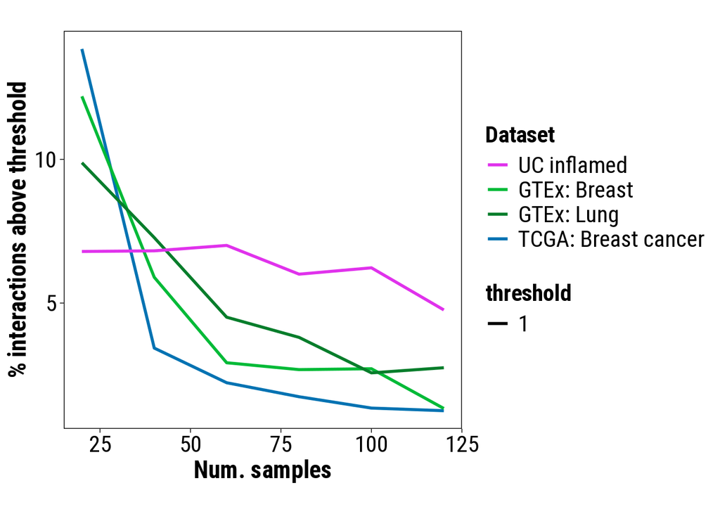

```r
aracne_strong_scores_plot <- aracne_strong_scores_df %>%
  ggplot(aes(x = ss, y = mean_percentage_above_threshold)) +
  geom_line(aes(col = rgb_col, linetype = threshold), size = 1) +
  scale_colour_identity(
    labels = unique(aracne_strong_scores_df$type_dataset),
    breaks = unique(aracne_strong_scores_df$rgb_col),
    guide = "legend"
  ) +
  xlab("Num. samples") +
  ylab("% interactions above threshold") +
  guides(col=guide_legend(title="Dataset")) +
  theme_linedraw() +
  theme(aspect.ratio = 1,
        plot.title = element_text(size = 20, face = "bold"),
        axis.title = element_text(size = 17, face = "bold"),
        axis.text = element_text(size = 16),
        panel.grid.major = element_blank(),
        panel.grid.minor = element_blank(),
        text = element_text(family = font_selected),
        legend.text = element_text(size = 16),
        legend.title=element_text(size=16, face="bold")
  )
print(aracne_strong_scores_plot)
```

Plot the % of strong correlations vs. sample size for GENIE3 networks:

```r
genie3_strong_scores_df <- strong_scores_results_df %>%
  dplyr::filter(method == "genie3") %>%
  dplyr::group_by(threshold, type_dataset, ss) %>%
  dplyr::summarize(mean_percentage_above_threshold = mean(percentage_above_threshold)) %>%
  dplyr::mutate(threshold = as.character(threshold)) %>%
  dplyr::inner_join( (name2color %>%
                        as.data.frame() %>%
                        dplyr::rename("rgb_col"=".") %>%
                        tibble::rownames_to_column("type_dataset")),
                     by=c("type_dataset") ) %>%
  dplyr::mutate(
    ss = as.numeric(ss),
    type_dataset = dplyr::recode(type_dataset, !!!id2name)
  )
```

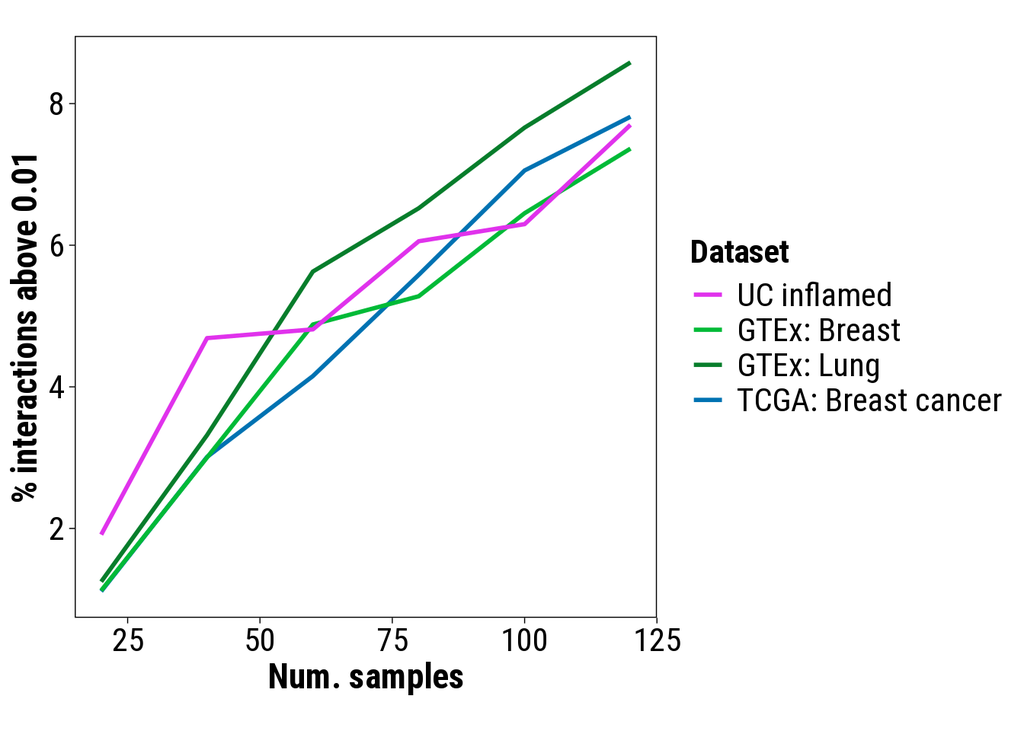

```r
genie3_strong_scores_plot <- genie3_strong_scores_df %>%
  ggplot(aes(x = ss, y = mean_percentage_above_threshold)) +
  geom_line(aes(col = rgb_col), size = 1) +
  scale_colour_identity(
    labels = unique(genie3_strong_scores_df$type_dataset),
    breaks = unique(genie3_strong_scores_df$rgb_col),
    guide = "legend"
  ) +
  xlab("Num. samples") +
  ylab("% interactions above 0.01") +
  guides(col=guide_legend(title="Dataset")) +
  theme_linedraw() +
  theme(aspect.ratio = 1,
        plot.title =  element_text(size = 20, face = "bold"),
        axis.title = element_text(size = 17, face = "bold"),
        axis.text = element_text(size = 16),
        panel.grid.major = element_blank(),
        panel.grid.minor = element_blank(),
        text = element_text(family = font_selected),
        legend.text = element_text(size = 16),
        legend.title=element_text(size=16, face="bold")
  )
print(genie3_strong_scores_plot)
```

Plot the % of strong correlations vs. sample size for different methods (selecting networks from the same data set):

[figure not shown]

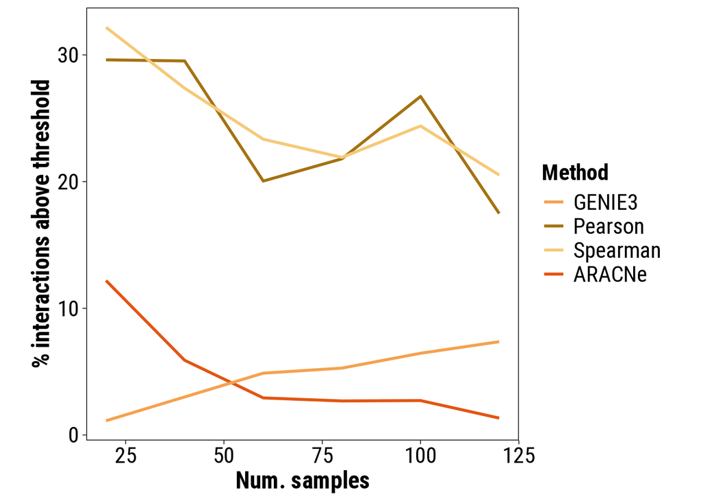

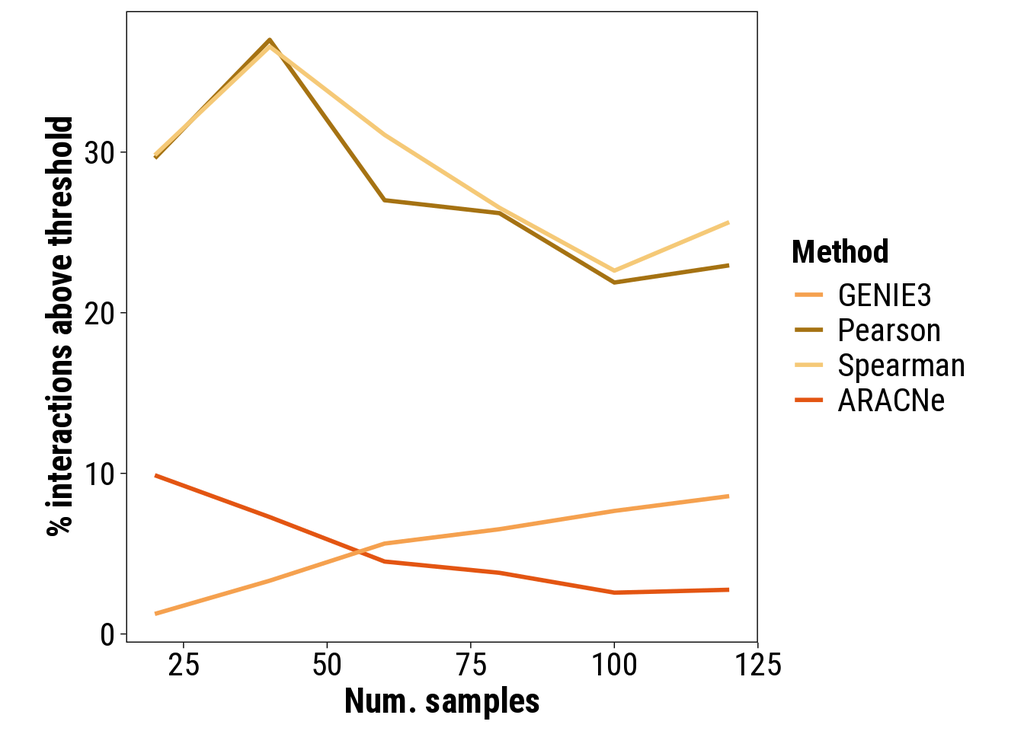

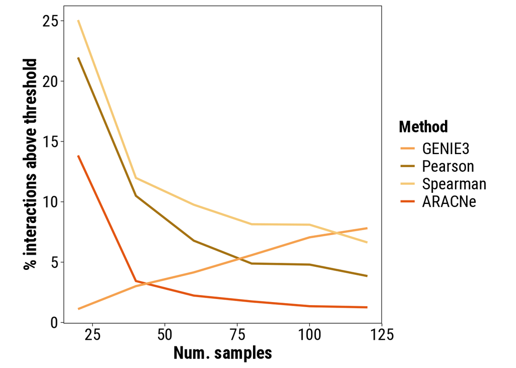

```r
strong_scores_by_method_plots <- list()
for (i in 1:length(datasets_selected)){
  type_dataset_sel = datasets_selected[[i]]
  strong_scores_by_method_df <- strong_scores_results_df %>%
    dplyr::filter(!((method == "aracne") & (threshold == 0))) %>%
    dplyr::filter(type_dataset == type_dataset_sel) %>%
    dplyr::group_by(threshold, method, ss) %>%
    dplyr::summarize(mean_percentage_above_threshold = mean(percentage_above_threshold)) %>%
    dplyr::mutate(threshold = as.character(threshold)) %>%
    dplyr::inner_join( (name2color %>%
                        as.data.frame() %>%
                        dplyr::rename("rgb_col"=".") %>%
                        tibble::rownames_to_column("method")),
                      by=c("method") ) %>%
    dplyr::mutate(
      ss = as.numeric(ss),
      method = dplyr::recode(method, !!!id2name)
    )

  strong_scores_by_method_plots[[type_dataset_sel]] <- strong_scores_by_method_df %>%
    ggplot(aes(x = ss, y = mean_percentage_above_threshold)) +
    geom_line(aes(col = rgb_col), size = 1) +
    scale_colour_identity(
      labels = unique(strong_scores_by_method_df$method),
      breaks = unique(strong_scores_by_method_df$rgb_col),
      guide = "legend"
    ) +
    xlab("Num. samples") +
    ylab("% interactions above threshold") +
    guides(col=guide_legend(title="Method")) +
    theme_linedraw() +
    theme(aspect.ratio = 1,
          plot.title =  element_text(size = 20, face = "bold"),
          axis.title = element_text(size = 17, face = "bold"),
          axis.text = element_text(size = 16),
          panel.grid.major = element_blank(),
          panel.grid.minor = element_blank(),
          text = element_text(family = font_selected),
          legend.text = element_text(size = 16),
          legend.title=element_text(size=16, face="bold")
    )
  print(strong_scores_by_method_plots[[type_dataset_sel]])
}
```